# EFleming DACSS 603 HW III

The following document contains my answers for DACSS 603 HW III.

Emerson Fleming (UMASS Amherst)  
3/23/22

## Question 1

(SMSS 11.2, except part (d))

For recent data in Jacksonville, Florida, on y = selling price of home (in dollars), x1 = size of home (in square feet), and x2 = lot size (in square feet), the prediction equation is ŷ = −10,536 + 53.8x1 + 2.84x2.

1. A particular home of 1240 square feet on a lot of 18,000 square feet sold for $145,000. Find the predicted selling price and the residual, and interpret.

$$Fl_house_predicted = −10,536 + 53.8*1240 + 2.84*18000$$

```
[1] 107296
```

```
[1] 37704
```

2. For fixed lot size, how much is the house selling price predicted to increase for each square-foot increase in home size? Why?

3. According to this prediction equation, for fixed home size, how much would lot size need to increase to have the same impact as a one-square-foot increase in home size?

For each square-foot increase in lot size, the selling price of the house increases by 2.84. Therefore, we need 53.8/2.84=18.9 sqft increase in lot size to create a 53.8 increase in selling price in dollars.

## Question 2

(ALR, 5.17, slightly modified)

(Data file: salary in alr4 R package). The data file concerns salary and other characteristics of all faculty in a small Midwestern college collected in the early 1980s for presentation in legal proceedings for which discrimination against women in salary was at issue. All persons in the data hold tenured or tenure track positions; temporary faculty are not included. The variables include degree, a factor with levels PhD and MS; rank, a factor with levels Asst, Assoc, and Prof; sex, a factor with levels Male and Female; Year, years in current rank; ysdeg, years since highest degree, and salary, academic year salary in dollars.

1. Test the hypothesis that the mean salary for men and women is the same, without regard to any other variable but sex. Explain your findings.

```
Call:
lm(formula = salary ~ sex, data = salary)

Residuals:
    Min      1Q  Median      3Q     Max
-8602.8 -4296.6  -100.8  3513.1 16687.9

Coefficients:
            Estimate Std. Error t value Pr(>|t|)
(Intercept)    24697        938  26.330   <2e-16 ***
sexFemale      -3340       1808  -1.847   0.0706 .
---
Signif. codes:  0 '***' 0.001 '**' 0.01 '*' 0.05 '.' 0.1 ' ' 1

Residual standard error: 5782 on 50 degrees of freedom
Multiple R-squared:  0.0639,    Adjusted R-squared:  0.04518
F-statistic: 3.413 on 1 and 50 DF,  p-value: 0.0706
```

```
[1] -0.2527824
```

```
    Male   Female
24696.79 21357.14
```

As we can see, a weak negative correlation exists between gender and salary. Also, the difference in average salaries for male and female appears to be around $3,000. this correlation is not strong enough for us to reject the null hypothesis. In fact, we must fail to reject the null hypothesis as the p-value is larger than 0.05

2. Run a multiple linear regression with salary as the outcome variable and everything else as predictors, including sex. Assuming no interactions between sex and the other predictors, obtain a 95% confidence interval for the difference in salary between males and females.

```
Call:
lm(formula = salary ~ ., data = salary[, c(-2, -9)])

Residuals:
    Min      1Q  Median      3Q     Max
-4045.2 -1094.7  -361.5   813.2  9193.1

Coefficients:
            Estimate Std. Error t value Pr(>|t|)
(Intercept) 15746.05     800.18  19.678  < 2e-16 ***
degreePhD    1388.61    1018.75   1.363    0.180
sexFemale    1166.37     925.57   1.260    0.214
year          476.31      94.91   5.018 8.65e-06 ***
ysdeg        -124.57      77.49  -1.608    0.115
Prof        11118.76    1351.77   8.225 1.62e-10 ***
Assoc        5292.36    1145.40   4.621 3.22e-05 ***
---
Signif. codes:  0 '***' 0.001 '**' 0.01 '*' 0.05 '.' 0.1 ' ' 1

Residual standard error: 2398 on 45 degrees of freedom
Multiple R-squared:  0.855, Adjusted R-squared:  0.8357
F-statistic: 44.24 on 6 and 45 DF,  p-value: < 2.2e-16
```

```
              2.5 %   97.5 %
sexFemale -697.8183 3030.565
```

We can say we are 95% sure average salary of Females minus Males falls within -697.8183 and 3030.565. We use Females minus Males as R used dummy variables so we must compensate. You normally want the confidence interval to be outside of “0.” Here, “0” is included. This is not suprising as the p-value does not give a statistically significant result (the p-value is too large).

3. Interpret your finding for each predictor variable; (i) discuss statistical significance “DegreePhd,” “ysdeg,” and “sexFemale” are not statistically significant as denoted by the p-value. Rank (which was converted into a numeric variable as academic rank as an ordinal variable) and “year” are all statistically significant as they have p-values close to zero.
2. interpretation of the coefficient / slope in relation to the outcome variable and other variables On average, Professors are earning $11118.76 more than Assistant Professors, while Associate Professors are earning 5292.36 dollars more than assistant professors. On average, one extra year in current rank leads to a $476.31 higher salary.
4. Change the baseline category for the rank variable. Interpret the coefficients related to rank again.

```
Call:
lm(formula = salary ~ ., data = salary[, c(-2, -7)])

Residuals:
    Min      1Q  Median      3Q     Max
-4045.2 -1094.7  -361.5   813.2  9193.1

Coefficients:
             Estimate Std. Error t value Pr(>|t|)
(Intercept)  26864.81    1375.29  19.534  < 2e-16 ***
degreePhD     1388.61    1018.75   1.363    0.180
sexFemale     1166.37     925.57   1.260    0.214
year           476.31      94.91   5.018 8.65e-06 ***
ysdeg         -124.57      77.49  -1.608    0.115
Assoc        -5826.40    1012.93  -5.752 7.28e-07 ***
Asst        -11118.76    1351.77  -8.225 1.62e-10 ***
---
Signif. codes:  0 '***' 0.001 '**' 0.01 '*' 0.05 '.' 0.1 ' ' 1

Residual standard error: 2398 on 45 degrees of freedom
Multiple R-squared:  0.855, Adjusted R-squared:  0.8357
F-statistic: 44.24 on 6 and 45 DF,  p-value: < 2.2e-16
```

5. Finkelstein (1980), in a discussion of the use of regression in discrimination cases, wrote, “[a] variable may reflect a position or status bestowed by the employer, in which case if there is discrimination in the award of the position or status, the variable may be ‘tainted.’” Thus, for example, if discrimination is at work in promotion of faculty to higher ranks, using rank to adjust salaries before comparing the sexes may not be acceptable to the courts. (i)Exclude the variable rank, refit, and summarize how your findings changed, if they did.

```
Call:
lm(formula = salary ~ degree + sex + year + ysdeg, data = salary)

Residuals:
    Min      1Q  Median      3Q     Max
-8146.9 -2186.9  -491.5  2279.1 11186.6

Coefficients:
            Estimate Std. Error t value Pr(>|t|)
(Intercept) 17183.57    1147.94  14.969  < 2e-16 ***
degreePhD   -3299.35    1302.52  -2.533 0.014704 *
sexFemale   -1286.54    1313.09  -0.980 0.332209
year          351.97     142.48   2.470 0.017185 *
ysdeg         339.40      80.62   4.210 0.000114 ***
---
Signif. codes:  0 '***' 0.001 '**' 0.01 '*' 0.05 '.' 0.1 ' ' 1

Residual standard error: 3744 on 47 degrees of freedom
Multiple R-squared:  0.6312,    Adjusted R-squared:  0.5998
F-statistic: 20.11 on 4 and 47 DF,  p-value: 1.048e-09
```

The coefficient of the sex variable is still not statistically significant which indicates no sexual gender discrimination. However, the ysdef variable did become statistically significant.

```
[1] 0.6957238
```

This result ysdeg is capturing (at least partially if not fully) the effect of rank versus as people with more years of experience after the highest degree also have higher academic ranks. The correlation between rank and ysdeg(0.696) also supports this argument.

6. Everyone in this dataset was hired the year they earned their highest degree. It is also known that a new Dean was appointed 15 years ago, and everyone in the dataset who earned their highest degree 15 years ago or less than that has been hired by the new Dean. Some people have argued that the new Dean has been making offers that are a lot more generous to newly hired faculty than the previous one and that this might explain some of the variation in Salary.

Create a new variable that would allow you to test this hypothesis and run another multiple regression model to test this. Select variables carefully to make sure there is no multicollinearity. Explain why multicollinearity would be a concern in this case and how you avoided it. Do you find support for the hypothesis that the people hired by the new Dean are making higher than those that were not?

```
Call:
lm(formula = salary ~ degree + ysdeg + sex + newhire, data = salary)

Residuals:
    Min      1Q  Median      3Q     Max
-8332.6 -2605.8  -865.1  2966.5 11030.9

Coefficients:
            Estimate Std. Error t value Pr(>|t|)
(Intercept) 18233.70    2796.72   6.520 4.38e-08 ***
degreePhD   -4246.07    1415.78  -2.999 0.004320 **
ysdeg         479.68     119.99   3.998 0.000224 ***
sexFemale   -2731.90    1250.83  -2.184 0.033982 *
newhire        78.15    2194.61   0.036 0.971743
---
Signif. codes:  0 '***' 0.001 '**' 0.01 '*' 0.05 '.' 0.1 ' ' 1

Residual standard error: 3979 on 47 degrees of freedom
Multiple R-squared:  0.5833,    Adjusted R-squared:  0.5478
F-statistic: 16.45 on 4 and 47 DF,  p-value: 1.713e-08
```

Here, we have created all new dummy variables that will serve as our means of analyzing a correlation between the new dean and offers being made. In order to avoid multicollinearity, we will remove variables with very high levels of correlation from our original model which would include rank and year.

The high p-value of salary with regards to “newhire” indicates we cannot claim new hires by the new dean are earning any higher salary than those hired by the previous dean.

```
[1] -0.8434239
```

```
[1] -0.7206038
```

```
[1] 0
```

The correlation between new dummy var and ysdeg is very high and can cause an issue with reagrds to multicollinearity.

I propose to simply drop ysdeg and run the regression with the degree, sex, year and newhire variables only. Additionally, we drop ysdeg and add rank dummies since the correlation between newhire and rank is a bit lower than the correlation between newhire and ysdeg. Rank can therefore proxy ysdeg.

```
Call:
lm(formula = salary ~ degree + year + sex + newhire + Prof +
    Assoc, data = salary)

Residuals:
    Min      1Q  Median      3Q     Max
-3403.3 -1387.0  -167.0   528.2  9233.8

Coefficients:
            Estimate Std. Error t value Pr(>|t|)
(Intercept) 13328.38    1483.38   8.985 1.33e-11 ***
degreePhD     818.93     797.48   1.027   0.3100
year          434.85      78.89   5.512 1.65e-06 ***
sexFemale     907.14     840.54   1.079   0.2862
newhire      2163.46    1072.04   2.018   0.0496 *
Prof        11096.95    1191.00   9.317 4.54e-12 ***
Assoc        4972.66     997.17   4.987 9.61e-06 ***
---
Signif. codes:  0 '***' 0.001 '**' 0.01 '*' 0.05 '.' 0.1 ' ' 1

Residual standard error: 2362 on 45 degrees of freedom
Multiple R-squared:  0.8594,    Adjusted R-squared:  0.8407
F-statistic: 45.86 on 6 and 45 DF,  p-value: < 2.2e-16
```

Correlation between new dummy variable and ysdeg is very high. Multicollinearity inflates standard errors and thus makes us fail to reject more eften (higher p-values). Here, those hired by the new dean gain higher salaries by an average of $2163.46 compared to the old dean.

## Question 3

(SMSS 13.7 & 13.8 combined, modified)

(Data file: house.selling.price in smss R package)

1. Using the house.selling.price data, run and report regression results modeling y = selling price (in dollars) in terms of size of home (in square feet) and whether the home is new (1 = yes; 0 = no). (In other words, price is the outcome variable and size and new are the explanatory variables.)

```
Call:
lm(formula = Price ~ Size + New, data = house.selling.price)

Residuals:
    Min      1Q  Median      3Q     Max
-205102  -34374   -5778   18929  163866

Coefficients:
              Estimate Std. Error t value Pr(>|t|)
(Intercept) -40230.867  14696.140  -2.738  0.00737 **
Size           116.132      8.795  13.204  < 2e-16 ***
New          57736.283  18653.041   3.095  0.00257 **
---
Signif. codes:  0 '***' 0.001 '**' 0.01 '*' 0.05 '.' 0.1 ' ' 1

Residual standard error: 53880 on 97 degrees of freedom
Multiple R-squared:  0.7226,    Adjusted R-squared:  0.7169
F-statistic: 126.3 on 2 and 97 DF,  p-value: < 2.2e-16
```

2. Report and interpret the prediction equation, and form separate equations relating selling price to size for new and for not new homes. In particular, for each variable; discuss statistical significance and interpret the meaning of the coefficient.

```
Call:
lm(formula = Price ~ Size + New, data = house.selling.price)

Residuals:
    Min      1Q  Median      3Q     Max
-205102  -34374   -5778   18929  163866

Coefficients:
              Estimate Std. Error t value Pr(>|t|)
(Intercept) -40230.867  14696.140  -2.738  0.00737 **
Size           116.132      8.795  13.204  < 2e-16 ***
New          57736.283  18653.041   3.095  0.00257 **
---
Signif. codes:  0 '***' 0.001 '**' 0.01 '*' 0.05 '.' 0.1 ' ' 1

Residual standard error: 53880 on 97 degrees of freedom
Multiple R-squared:  0.7226,    Adjusted R-squared:  0.7169
F-statistic: 126.3 on 2 and 97 DF,  p-value: < 2.2e-16
```

price = -40230,867 + 116.132 * size + 57736.283*New -> For whole sample

Houses with 1 more sqft in size on average sell at a $116 higher price. New homes on average are 57736 (dollars) more expensive than not new homes.

There appears to be a very high correlation between price and size of the house and a high correlation between whether the house is new and price as denoted by the p-values. Overall, there is a larger correlation between price and size of the home as opposed to whether it is new. All coefficients are statistically significant and under 5%.

3. Find the predicted selling price for a home of 3000 square feet that is (i) new, (ii) not new.

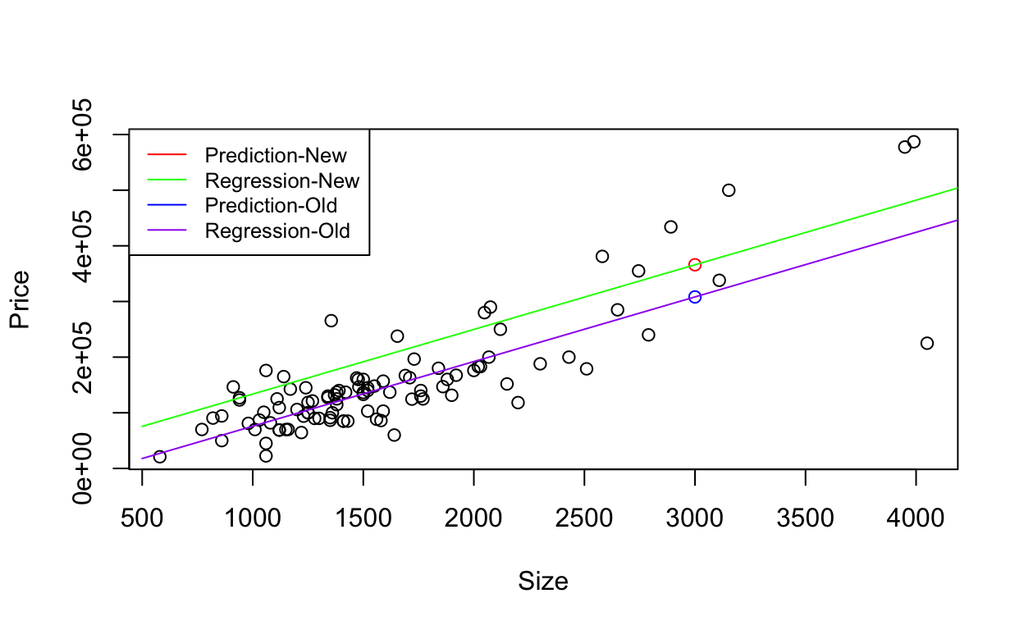

4. Fit another model, this time with an interaction term allowing interaction between size and new, and report the regression results

```
Call:
lm(formula = Price ~ Size * New, data = house.selling.price)

Residuals:
    Min      1Q  Median      3Q     Max
-175748  -28979   -6260   14693  192519

Coefficients:
              Estimate Std. Error t value Pr(>|t|)
(Intercept) -22227.808  15521.110  -1.432  0.15536
Size           104.438      9.424  11.082  < 2e-16 ***
New         -78527.502  51007.642  -1.540  0.12697
Size:New        61.916     21.686   2.855  0.00527 **
---
Signif. codes:  0 '***' 0.001 '**' 0.01 '*' 0.05 '.' 0.1 ' ' 1

Residual standard error: 52000 on 96 degrees of freedom
Multiple R-squared:  0.7443,    Adjusted R-squared:  0.7363
F-statistic: 93.15 on 3 and 96 DF,  p-value: < 2.2e-16
```

5. Report the lines relating the predicted selling price to the size for homes that are (i) new, (ii) not new.
1. Price = -22227.808 + 104.438 * Size - 78527.502 * 1 + 61.916 * Size * 1 Price = -100755.3 + 166.354 * Size
2. Price = -22227.808 + 104.438 * Size - 78527.502 * 0 + 61.916 * Size * 0 Price = -22227.808 + 104.438 * Size (Old homes)
6. Find the predicted selling price for a home of 3000 square feet that is
1. new, (ii) not new.

```
       1        2
398307.5 291087.4
```

7. Find the predicted selling price for a home of 1500 square feet that is (i) new, (ii) not new. Comparing to (F), explain how the difference in predicted selling prices changes as the size of home increases.

```
       1        2
148776.1 134429.8
```

1500 sqft bigger size corresponds to 398307-148776.1=249531.4 and 291087.4-134429.8=156657.6 higher price for new and hold homes respectively.

8. Do you think the model with interaction or the one without it represents the relationship of size and new to the outcome price? What makes you prefer one model over another?

I prefer the second model as the coefficient of interaction var is statistically significant and adjusted r^2 goes up when we add the interaction.